# Supplemental Figures

Sean Maden

10/8/2020

# Figure S1

Obtain sample (GSM IDs) and study (GSE IDs) summaries from queries to GEO with queries to Entrez utilities. With [Entrez utilities](https://www.ncbi.nlm.nih.gov/books/NBK179288/) installed, navigate to the directory with the script “eqplot.py” and run:

```
python3 eqplot.py
```

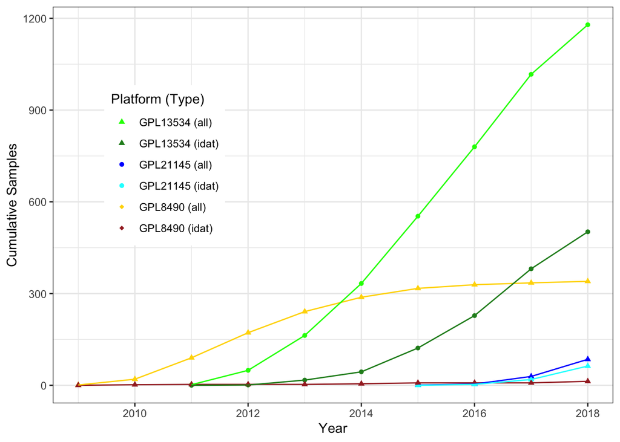

```r
script.name <- "figS1.R"
source(file.path(scripts.dir, script.name))
figS1
```

# Figure S2

```r
script.name <- "figS2.R"
source(file.path(scripts.dir, script.name))
figS2
```

[output not shown]

# Figure S3

```r
script.name <- "figS3.R"
source(file.path(scripts.dir, script.name))
figS3
```

[output not shown]

# Figure S4

```r
script.name <- "figS4.R"
source(file.path(scripts.dir, script.name))
figS4
```

[output not shown]

# Figure S5

```r
script.name <- "figS5.R"
source(file.path(scripts.dir, script.name))
figS5
```

[output not shown]

# Figure S6

Details including sample identification, analyses, and results summaries are detailed in the script `pca_fig3.R`. This script generates the files contained in /Library/Frameworks/R.framework/Versions/4.0/Resources/library/recountmethylationManuscriptSupplement/extdata/pcadata, which are used below to generate the main plots.

```r
script.name <- "figS6.R"
source(file.path(scripts.dir, script.name))
figS6a
```

[output not shown]

```r
figS6b
```

[output not shown]

# Figure S7

This section shows how to generate the data summary plots for DNAm variability analyses in 7 noncancer tissues. Source the script to generate the barplots summarizing studies and samples (fig7b) and the anova filter summary stacked barplot.

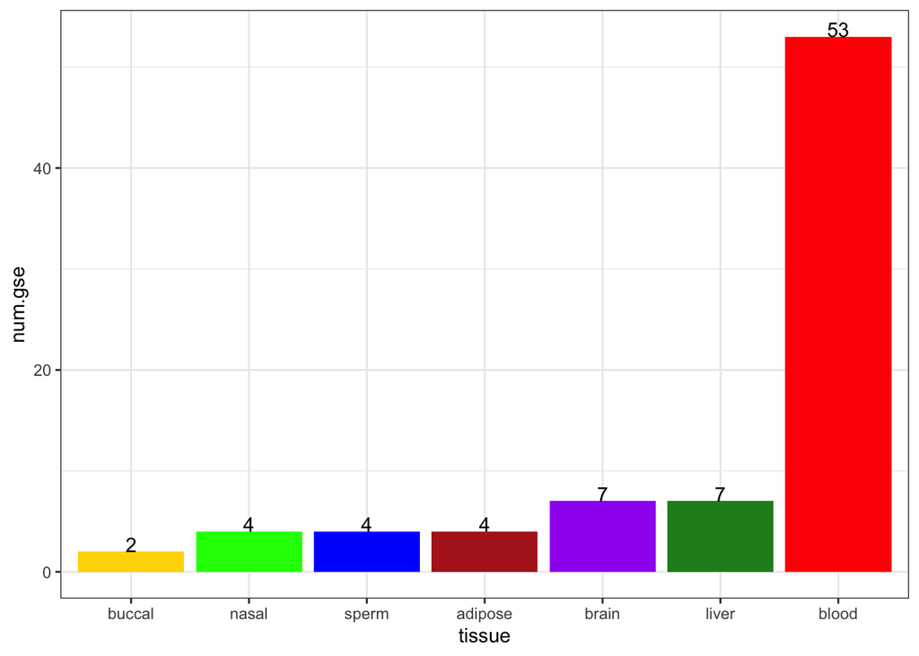

```r
script.name <- "figS7.R"
source(file.path(scripts.dir, script.name))
figS7b.studies
```

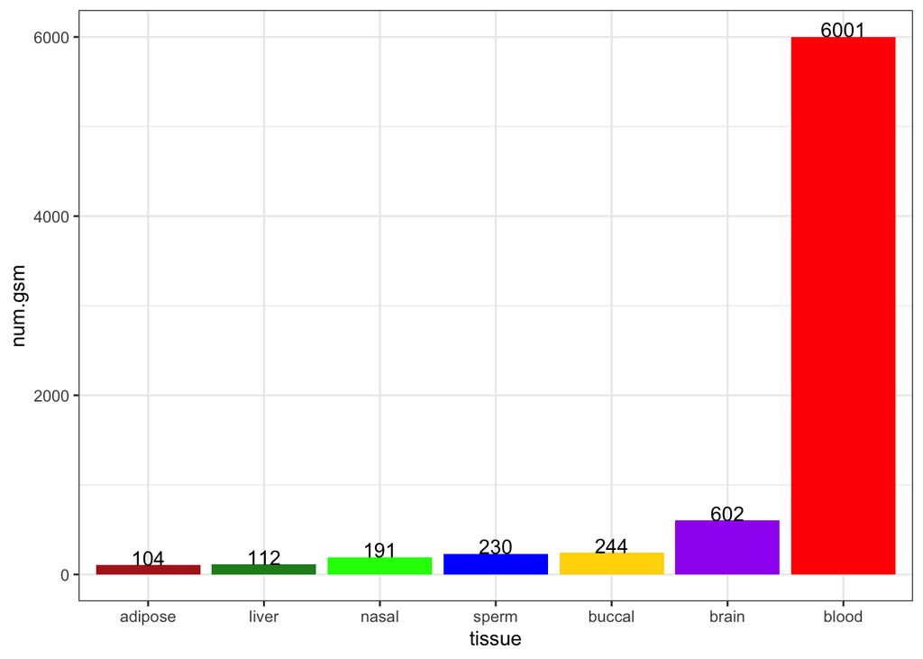

```r
figS7b.samples
```

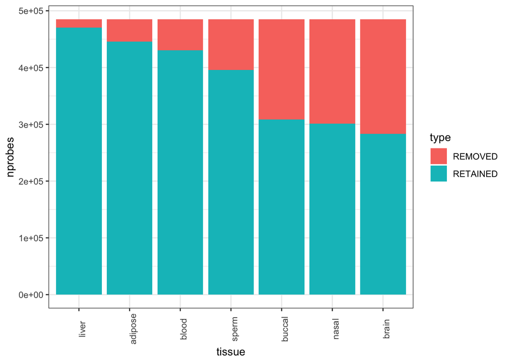

```r
figS7c
```

# Figure S8

This section shows how to generate a composite of stacked barplots summarizing genome mapping patterns in probes with low variance across 7 noncancer tissues.

```
## locfit 1.5-9.4    2020-03-24
```

```
## Setting options('download.file.method.GEOquery'='auto')
```

```
## Setting options('GEOquery.inmemory.gpl'=FALSE)
```

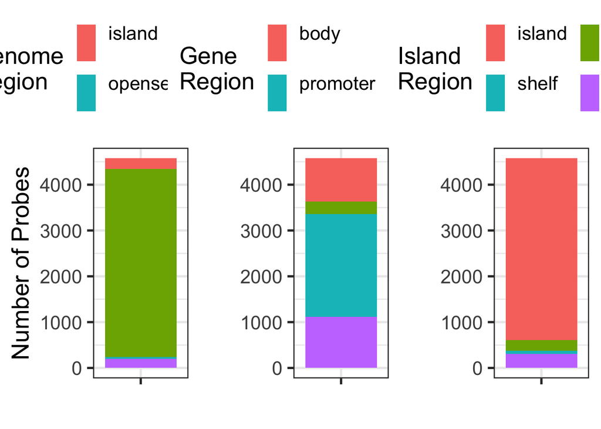

```r
script.name <- "figS8.R"
source(file.path(scripts.dir, script.name))
```

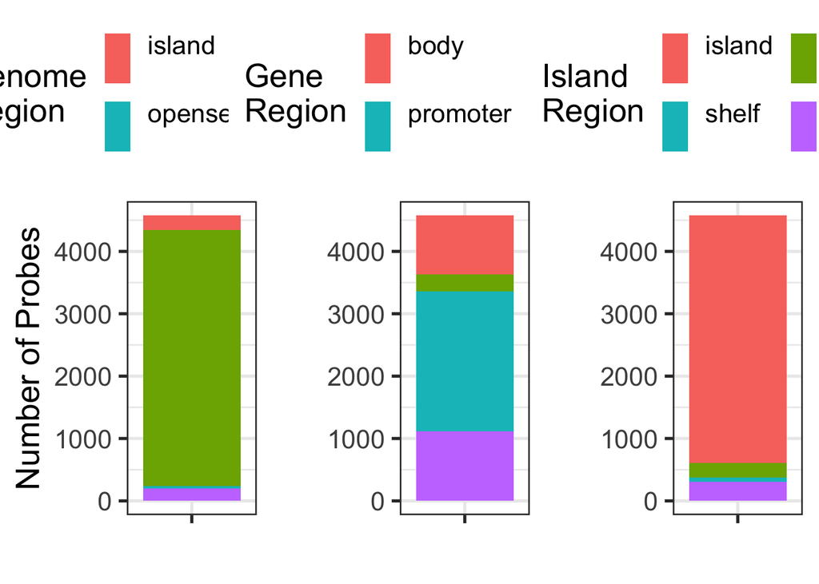

```r
grid.arrange(figS8.plot1, figS8.plot2, figS8.plot3, ncol = 3)
```